# Stat 480 - Homework #6

2/22/2018

## Ames housing

1. Download the RMarkdown file with these homework instructions to use as a template for your work. Make sure to replace “Your Name” in the YAML with your name.
2. The Ames based, non-profit company OAITI provides aoe open-source data sets. One of these data sets consists of information on all house sales in Ames between 2008 and 2010. The following piece of code allows you to read the dataset into your R session.

How many house sales were there between 2008 and 2010? Which type of variables are we dealing with?

```r
housing <- read.csv("https://raw.githubusercontent.com/OAITI/open-datasets/master/Housing%20Data/Ames-Housing.csv")
```

loading libraries:

```r
library(ggplot2)
library(dplyr)
```

inspecting data set:

```r
str(housing)
```

```
## 'data.frame':    1615 obs. of  10 variables:
##  $ SalePrice   : int  215000 124500 105000 172000 176500 157000 244000 237500 206900 345000 ...
##  $ Bedrooms    : int  3 2 2 3 3 4 3 4 4 4 ...
##  $ Baths       : int  1 1 1 1 1 2 2 2 2 2 ...
##  $ LotArea     : int  31770 13008 11622 14267 11029 10200 11160 12925 11075 13860 ...
##  $ LivingArea  : int  1656 882 896 1329 1414 1434 2110 2117 2112 2704 ...
##  $ GarageArea  : int  528 502 730 312 601 528 522 550 576 538 ...
##  $ Neighborhood: Factor w/ 33 levels "Blmngtn","Blueste",..: 19 19 19 19 19 19 19 19 19 19 ...
##  $ HouseStyle  : Factor w/ 8 levels "1-Story","1.5 Fin",..: 1 1 1 1 1 1 1 1 4 8 ...
##  $ YearBuilt   : int  1960 1956 1961 1958 1958 1974 1968 1970 1969 1972 ...
##  $ YearSold    : int  2010 2009 2010 2010 2008 2009 2010 2008 2008 2009 ...
```

Answer: 1615 houses were sold in Ames between 2008 and 2010. The dataset consists of integers and factor variables.

3. Do sales prices change over time? (Don’t test significances) Provide a graphic that supports your statement.

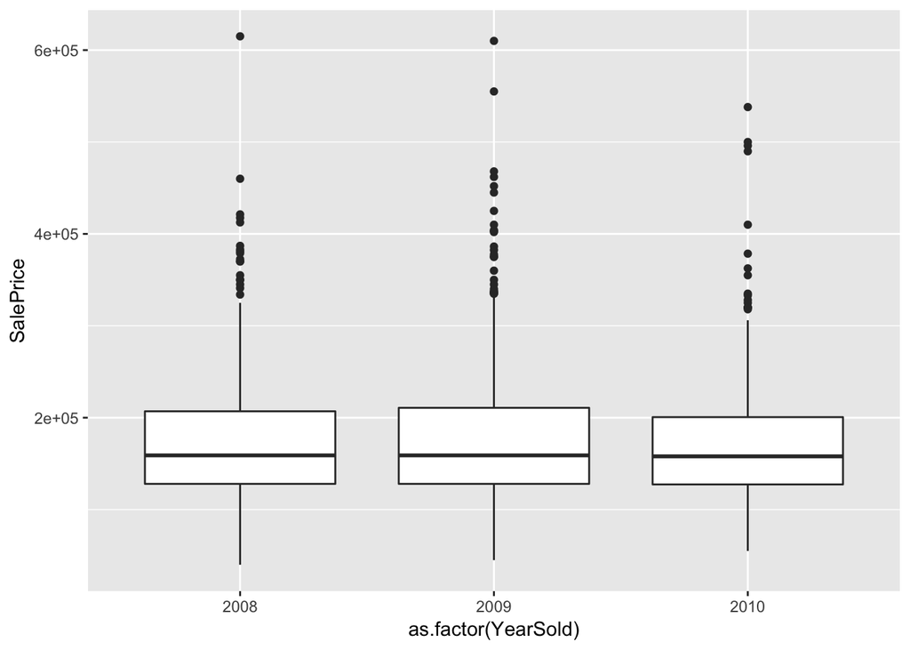

```r
housing %>%
        ggplot(aes(x= as.factor(YearSold), y=SalePrice)) + geom_boxplot()
```

Sale prices are pretty consistent from 2008 to 2010. The median sales price between years looks fairly similar with several houses in each year having high price outliers.

4. What is the relationship between sales prices and the size of the house (living area)? Make a chart and describe the relationship.

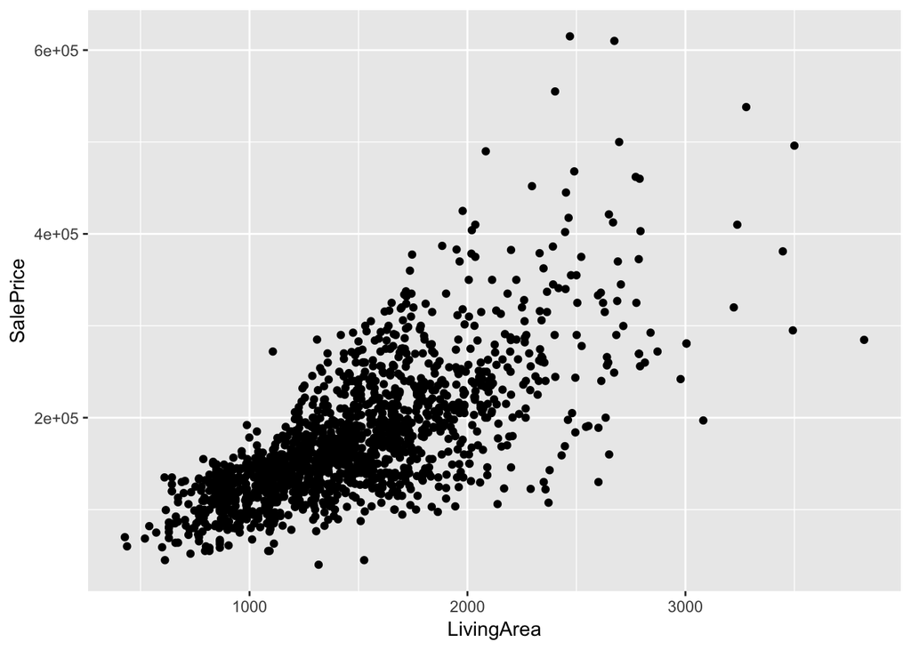

```r
ggplot(data = housing, aes (x = LivingArea, y =SalePrice)) + geom_point()
```

5. Use `dplyr` functions to:
- introduce a variable consisting of price per square foot
- find the average price per square foot in each of the Ames neighborhoods,
- exclude averages that are based on fewer than 10 records,
- reorder the remaining neighborhoods according to the mean sales prices.
6. Draw a chart of the average sale prices by neighborhood and comment on it. Only consider neighborhoods with at least 10 sales.  
   *Extra challenge* (0.5 point extra credit): write the code for this question and the previous one in a single statement.

```r
  summary(housing$Neighborhood)
```

```
## Blmngtn Blueste Br'Dale BrkSide ClearCr CollgCr Crawfor DakotaR Edwards
##      25      19      16      63      26     145      47       5      95
## Gilbert  Greens GrnHill IDOT&RR IOCondo Landmrk MeadowV Mitchel MsCondo
##      92       3      22      39      10      20      21      64       5
##  N Ames NoRidge NPkVill NridgHt NW Ames OldTown S&W ISU  Sawyer SawyerW
##     231      38      17      68      74     127      30      74      79
## Somerst StoneBr  Timber Veenker WllwCr1 WllwCr2
##      85      20      34       9       6       6
```

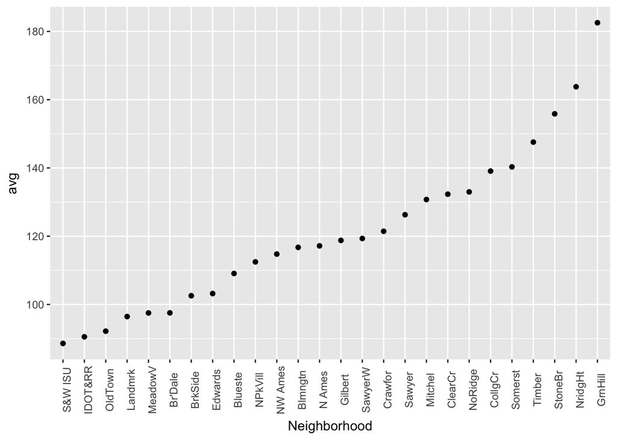

```r
housing %>%
    mutate(PriceSqFt = SalePrice/(LivingArea)) %>%
    group_by(Neighborhood) %>%
      summarise(
        n = n(),
        avg = mean(PriceSqFt, na.rm = TRUE)
        ) %>%
        filter( n > 10) %>%
          mutate(Neighborhood = reorder(Neighborhood, avg)) %>%
            ggplot(aes(x = Neighborhood, y =avg)) + geom_point() + theme(axis.text.x = element_text(angle =90))
```

7. Use `dplyr` functions to:
- introduce a logical variable called ‘garage’ that is FALSE if the garage area is zero, and TRUE otherwise,
  - exclude all sales of houses that do not have a garage,
- only consider 1 and 2 story houses (`HouseStyle`),
- create a new variable `YBCut` from `YearBuilt` that introduces age categories that groups the year a house was built into intervals: 1800-1850, 1850-1900, 1950-2000, 2000+ (see `?cut`).
8. Draw a chart of the previous data set. Draw side-by-side boxplots of the garage area by `YBCut`. Facet by the style of house. Describe and summarise the chart.  
   *Extra challenge* (0.5 point extra credit): write the code for this question and the previous one in a single statement.

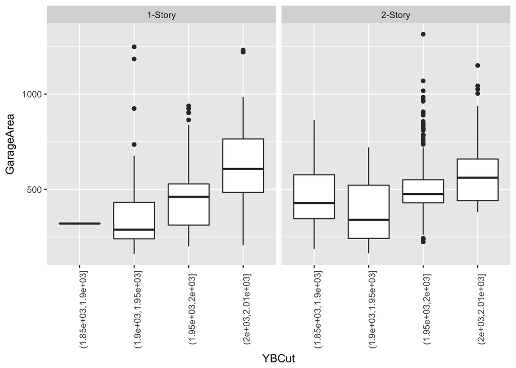

```r
housing %>%
  mutate( Garage = GarageArea != 0) %>%
    filter (Garage == TRUE, HouseStyle == "1-Story" | HouseStyle == "2-Story") %>%
    mutate (YBCut = cut(YearBuilt,breaks = c(1800,1850,1900,1950,2000,2010), dig.labels = 4)) %>%
   ggplot(aes(x = YBCut, y = GarageArea)) + geom_boxplot() + facet_wrap(~HouseStyle) + theme(axis.text.x = element_text(angle =90))
```

Due date: the homework is due before class on Thursday.

For the submission: submit your solution in an R Markdown file and (just for insurance) submit the corresponding html file with it.